# Super El Niño · modul 9

## Hvad handlede 11.5 om?

Hvorfor er det bedre at producere fødevarer lokalt?

Hvad krævede den grønne revolution af landmændene?

- **1960’erne**Den grønne revolution: nye sorter af ris og korn i Asien og Latinamerika.
- **2006**AGRA, Alliancen for Grøn Revolution i Afrika, bliver grundlagt.
- **2023/24**El Niño giver tørke i Malawi midt i majsens vækstsæson.
- **2026**Dyr gødning på grund af Hormuz, og en ny El Niño.

## Hvorfor halter Afrika efter?

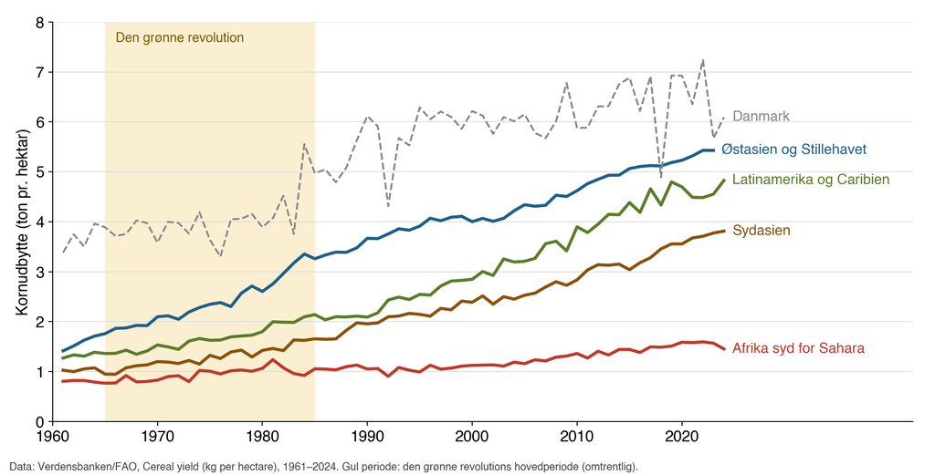

## Bread from the air

Planter skal bruge kvælstof (N) for at danne proteiner.

Luften er 78 % kvælstof (N₂), men planterne kan ikke optage det direkte.

I dag er omkring halvdelen af verdens befolkning afhængig af mad, der er dyrket med kvælstof fra luften.

- **Før 1900**Husdyrgødning, bælgplanter og importeret guano og chilesalpeter.
- **1909**Fritz Haber binder kvælstof fra luften i laboratoriet.
- **1913**Carl Bosch og firmaet BASF laver det i stor skala.
- **1960’erne**Den grønne revolution: nye sorter, der kræver meget kunstgødning.

Halvdelen af befolkningen: Erisman m.fl. (2008), *Nature Geoscience* 1, s. 636–639.

## Haber–Bosch-processen

**Naturgas + vanddamp**CH₄ + H₂O

→

**Brint**H₂ (og CO₂)

**Kvælstof fra luften**N₂

+

**Ammoniak**N₂ + 3 H₂ → 2 NH₃  
400–500 °C og 150–300 bar

→

**Kunstgødning**fx urea: NH₃ + CO₂

**Naturgas bruges to gange**

Gassen er råstof til brinten og energi til den høje temperatur og det høje tryk. Når naturgas bliver dyr, bliver kvælstofgødning dyr.

## Hvem producerer, og hvem køber?

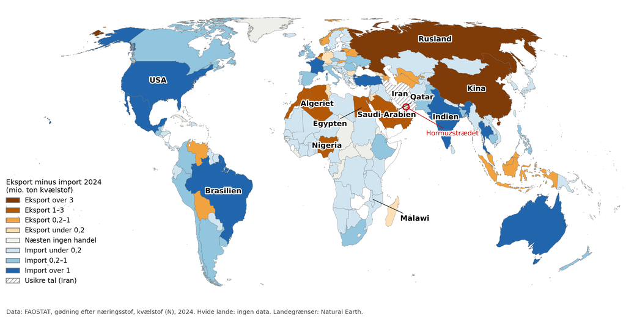

## Hvad betyder det for Malawi?

Malawi producerer ingen kvælstofgødning og importerede ca. 97.000 ton kvælstof i 2024.

Malawi har ingen kyst, så gødningen skal fragtes fra havne i nabolandene.

Hvorfor blev gødning så dyr i 2022?

Dyrere naturgas

Dyrere ammoniak og urea på verdensmarkedet

Dyrere import, især med svag valuta og lang transport

Landmændene køber mindre gødning

Mindre høst næste år

Data: FAOSTAT, gødning efter næringsstof, kvælstof (N), 2024.